# Project3

Nathan Waters, Lerone Williams

Tuesday, March 3, 2015

In this R Markdown document we will display and document each step of CS329e R Project 3 .

Project Requirements http://www.cs.utexas.edu/~cannata/dataVis/Projects/R%20Project%203/R%20Project%20Requirements.html.

In the source folder 01 Data, the R script Access Oracle Database.R was created to connect to Dr. Cannata’s Orcale database and generate a data frame from the uploaded ABOVE4CALI.csv and ABOVE4OU.csv files. First the data was pulled using a join SQL query, then the two datasets were piped to ggplot to display the results. The RCurl and jsonlite package were loaded to allow general HTTP requests and process the results returned by the Web server.

```r
source("../01 Data/Access Oracle Database.R", echo = TRUE)
```

```
##
## > require("RCurl")
```

```
##
## > require("jsonlite")
```

```
##
## > require("dplyr")
```

```
##
## > require("ggplot2")
```

```
##
## > quake <- data.frame(fromJSON(getURL(URLencode("129.152.144.84:5001/rest/native/?query=\"SELECT Distinct r1.LATITUDE, r1.LONGITUDE, r1.PLACE, r2.LATI .... [TRUNCATED]
##
## > quake %>% ggplot(aes(x = LATITUDE, y = LONGITUDE,
## +     color = PLACE)) + geom_point()
```

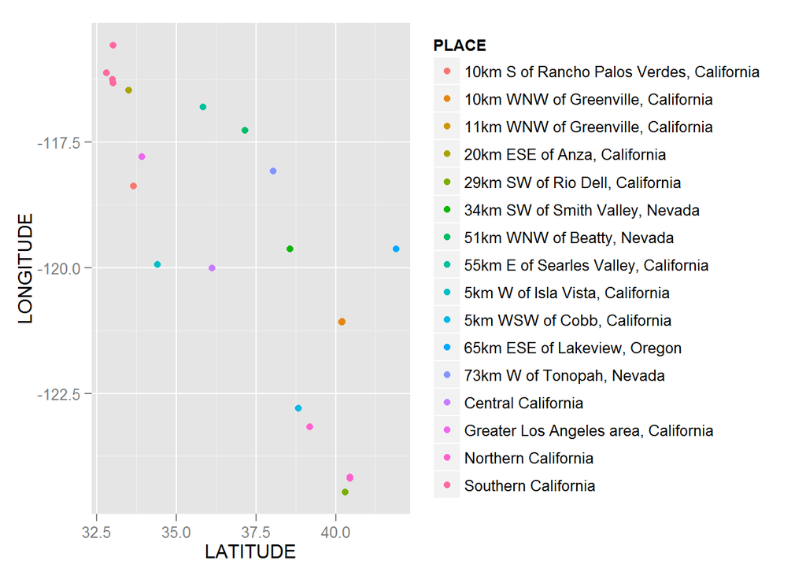

This screen capture depicts the actual area represented in the Above4OU dataset.

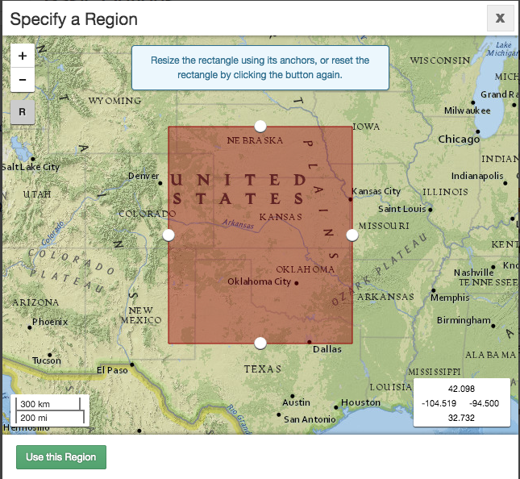

This screen capture depicts the actual are represented in the Above4CALI datase.

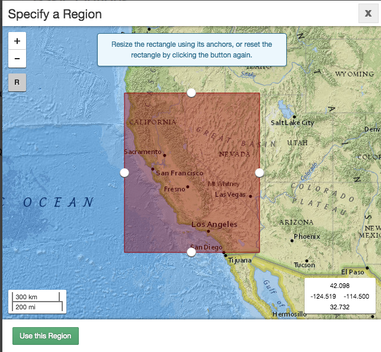

A second R script Subset.R was created to display the quake data frame that was previously created in the last step. The head(), tail(), tbl_df(), glimpse(), summary(), and str() functions were used to return subsets of this data frame.

```r
source("../01 Data/Subset Data.R", echo = TRUE)
```

```
##
## > require("dplyr")
##
## > head(quake)
##   LATITUDE LONGITUDE                              PLACE LATITUDE.1
## 1  40.1743 -121.0695 10km WNW of Greenville, California    35.9474
## 2  40.1743 -121.0695 10km WNW of Greenville, California    36.6028
## 3  40.1743 -121.0695 10km WNW of Greenville, California    36.3187
## 4  40.1743 -121.0695 10km WNW of Greenville, California    36.8076
## 5  40.1860 -121.0632 10km WNW of Greenville, California    35.8913
## 6  40.2858 -124.4603    29km SW of Rio Dell, California    37.2447
##   LONGITUDE.1                       PLACE.1 MAG MAG.1
## 1    -96.7642    4km S of Cushing, Oklahoma 4.0   4.0
## 2    -97.6068 25km SSE of Medford, Oklahoma 4.0   4.0
## 3    -96.7553   4km ESE of Pawnee, Oklahoma 4.0   4.0
## 4    -98.3716 6km NNW of Cherokee, Oklahoma 4.0   4.0
## 5    -97.2752 6km SSW of Langston, Oklahoma 4.2   4.2
## 6    -97.9553      7km SE of Harper, Kansas 4.3   4.3
##
## > tail(quake)
##     LATITUDE LONGITUDE               PLACE LATITUDE.1 LONGITUDE.1
## 145   40.437  -124.163 Northern California    35.7745    -97.4826
## 146   40.443  -124.186 Northern California    35.1920    -97.3200
## 147   36.120  -120.000  Central California    35.5530    -96.7520
## 148   36.120  -120.000  Central California    35.8930    -97.2920
## 149   36.120  -120.000  Central California    35.5956    -97.3924
## 150   33.004  -115.569 Southern California    36.1309    -97.6291
##                           PLACE.1 MAG MAG.1
## 145 12km SSW of Guthrie, Oklahoma 4.0   4.0
## 146                      Oklahoma 4.4   4.4
## 147                      Oklahoma 4.1   4.1
## 148 6km SSW of Langston, Oklahoma 4.1   4.1
## 149    8km N of Spencer, Oklahoma 4.1   4.1
## 150  20km N of Crescent, Oklahoma 4.2   4.2
##
## > tbl_df(quake)
## Source: local data frame [150 x 8]
##
##    LATITUDE LONGITUDE                                     PLACE LATITUDE.1
## 1   40.1743 -121.0695        10km WNW of Greenville, California    35.9474
```

[output cut: 54 more lines]

```
##  Mean   :4.128
##  3rd Qu.:4.200
##  Max.   :4.900
##
##
## > str(quake)
## 'data.frame':    150 obs. of  8 variables:
##  $ LATITUDE   : num  40.2 40.2 40.2 40.2 40.2 ...
##  $ LONGITUDE  : num  -121 -121 -121 -121 -121 ...
##  $ PLACE      : Factor w/ 16 levels "10km S of Rancho Palos Verdes, California",..: 2 2 2 2 2 5 1 8 16 16 ...
##  $ LATITUDE.1 : num  35.9 36.6 36.3 36.8 35.9 ...
##  $ LONGITUDE.1: num  -96.8 -97.6 -96.8 -98.4 -97.3 ...
##  $ PLACE.1    : Factor w/ 26 levels "12km ENE of Luther, Oklahoma",..: 12 8 11 14 15 16 14 25 21 14 ...
##  $ MAG        : num  4 4 4 4 4.2 ...
##  $ MAG.1      : num  4 4 4 4 4.2 ...
```

In this data wrangling section, several work flows are constructed using the %>% pipe operator, ggplot and join functions listed in the “Combine Data Sets” column of the Data Wrangling Cheatsheet. Specifically, left_join(), right_join(), innner_join(), full_join(), semi_join(), and anti_join() are used to combine and plot the ABOVE4CALI and ABOVE4OU datasets.

```r
source("../02 Data Wrangling/Joining Data.R", echo = TRUE)
```

```
##
## > require("RCurl")
##
## > require("jsonlite")
##
## > require("dplyr")
##
## > require("tidyr")
```

```
##
## > require("ggplot2")
##
## > Above4cali <- data.frame(fromJSON(getURL(URLencode("129.152.144.84:5001/rest/native/?query=\"SELECT * FROM ABOVE4CALI WHERE ROWNUM <= 35\""),
## +     .... [TRUNCATED]
##
## > Above4OU <- data.frame(fromJSON(getURL(URLencode("129.152.144.84:5001/rest/native/?query=\"SELECT * FROM ABOVE4OU WHERE ROWNUM <= 35\""),
## +     htt .... [TRUNCATED]
##
## > Recentca <- data.frame(fromJSON(getURL(URLencode("129.152.144.84:5001/rest/native/?query=\"SELECT * FROM RECENTCA WHERE ROWNUM <= 35\""),
## +     htt .... [TRUNCATED]
##
## > Recentou <- data.frame(fromJSON(getURL(URLencode("129.152.144.84:5001/rest/native/?query=\"SELECT * FROM RECENTOU WHERE ROWNUM <= 35\""),
## +     htt .... [TRUNCATED]
##
## > names(Above4OU)
##  [1] "TIME"      "LATITUDE"  "LONGITUDE" "DEPTH"     "MAG"
##  [6] "MAGTYPE"   "NST"       "GAP"       "DMIN"      "RMS"
## [11] "NET"       "ID"        "UPDATED"   "PLACE"     "TYPE"
##
## > names(Above4cali)
##  [1] "TIME"      "LATITUDE"  "LONGITUDE" "DEPTH"     "MAG"
##  [6] "MAGTYPE"   "NST"       "GAP"       "DMIN"      "RMS"
## [11] "NET"       "ID"        "UPDATED"   "PLACE"     "TYPE"
##
## > names(Recentca)
##  [1] "TIME"      "LATITUDE"  "LONGITUDE" "DEPTH"     "MAG"
##  [6] "MAGTYPE"   "NST"       "GAP"       "DMIN"      "RMS"
## [11] "NET"       "ID"        "UPDATED"   "PLACE"     "TYPE"
##
## > names(Recentou)
##  [1] "TIME"      "LATITUDE"  "LONGITUDE" "DEPTH"     "MAG"
##  [6] "MAGTYPE"   "NST"       "GAP"       "DMIN"      "RMS"
## [11] "NET"       "ID"        "UPDATED"   "PLACE"     "TYPE"
##
## > left_join(Above4cali, Above4OU, by = "MAG") %>% ggplot(aes(x = LATITUDE.x,
## +     y = LONGITUDE.x, color = PLACE.x)) + geom_point()
```

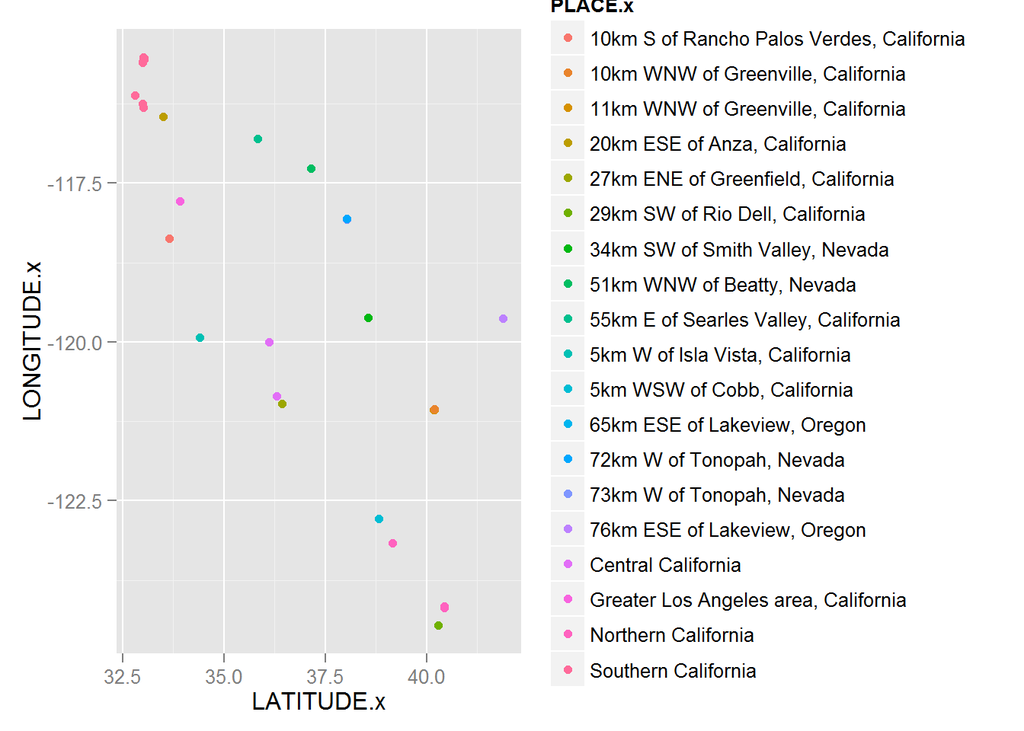

```
##
## > right_join(Above4cali, Above4OU, by = "DEPTH") %>%
## +     ggplot(aes(x = LATITUDE.x, y = LONGITUDE.x, color = PLACE.x)) +
## +     geom_point()
```

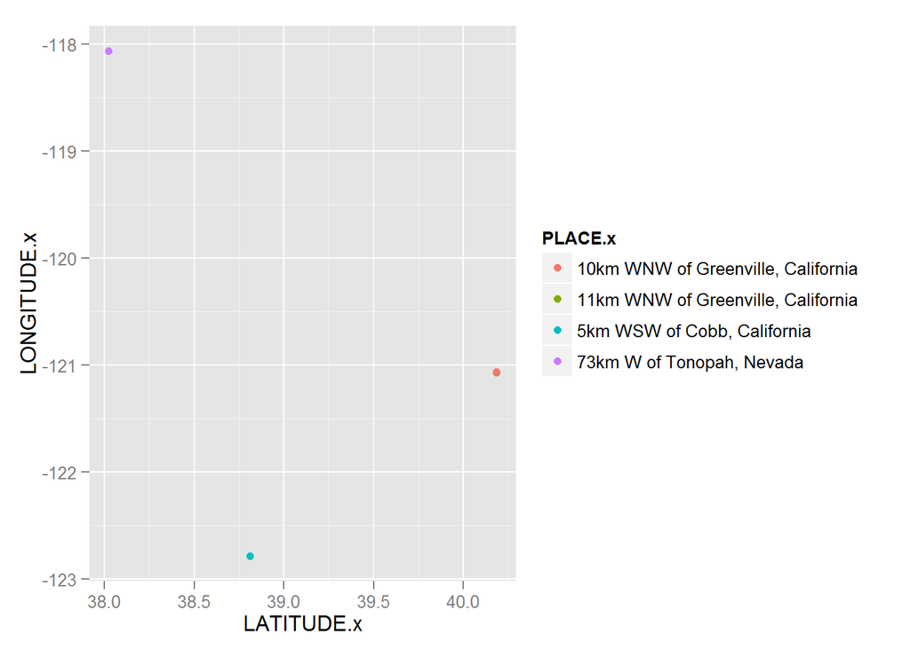

```
##
## > inner_join(Above4cali, Above4OU, by = "MAG") %>% ggplot(aes(x = LATITUDE.x,
## +     y = LONGITUDE.x, color = PLACE.x)) + geom_point()
```

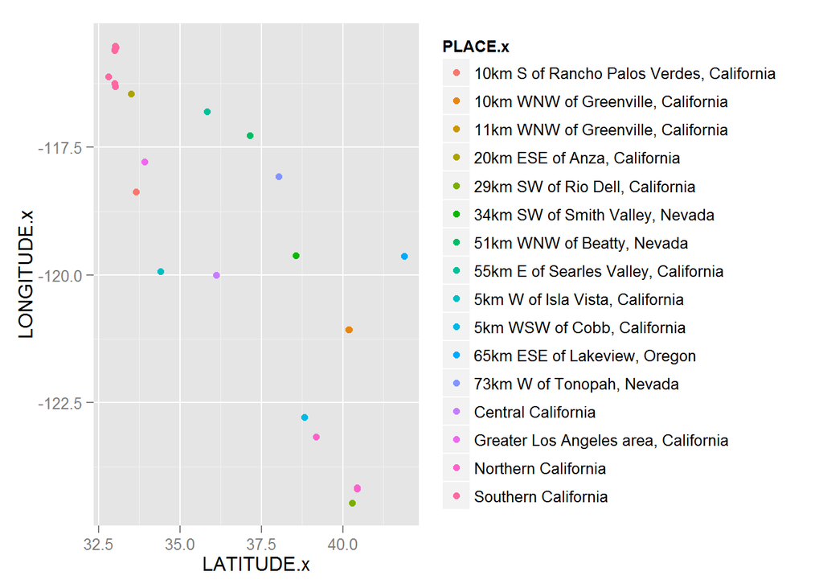

```
##
## > full_join(Above4cali, Above4OU, by = "DEPTH") %>%
## +     ggplot(aes(x = LATITUDE.x, y = LONGITUDE.x, color = PLACE.x)) +
## +     geom_point()
```

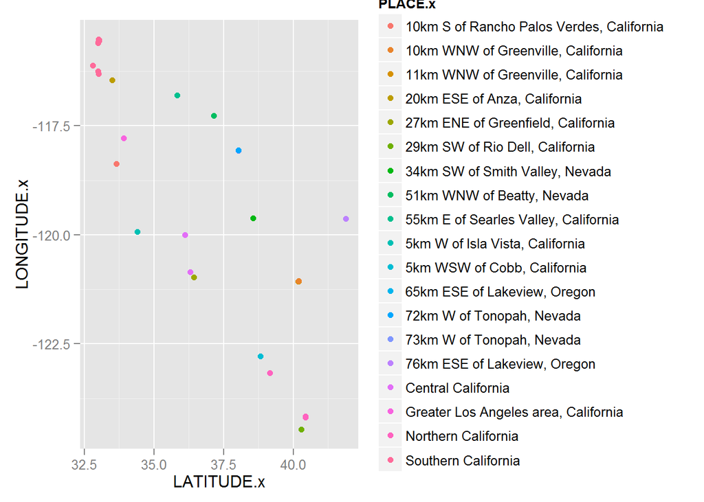

```
##
## > semi_join(Above4cali, Above4OU, by = "MAG") %>% ggplot(aes(x = LATITUDE,
## +     y = LONGITUDE, color = PLACE)) + geom_point()
```

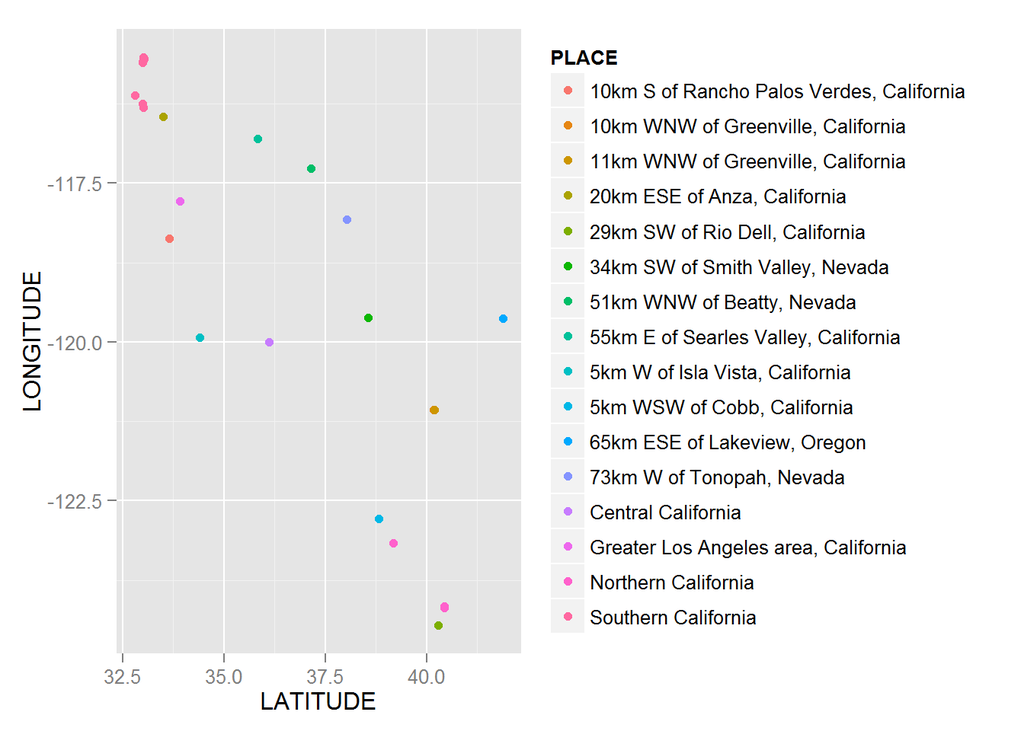

```
##
## > anti_join(Above4cali, Above4OU, by = "DEPTH") %>%
## +     ggplot(aes(x = LATITUDE, y = LONGITUDE, color = PLACE)) +
## +     geom_point()
```

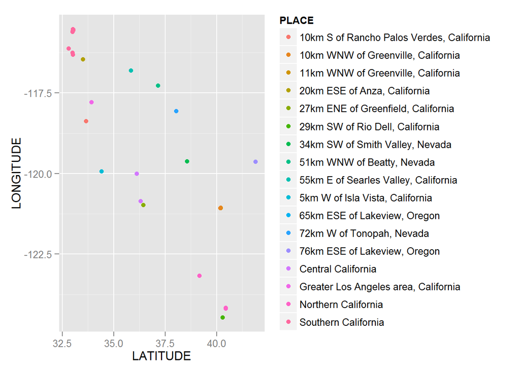

These next visualizations display our wrangled data sets incorporating Beautiful Plotting.

```r
source("../02 Data Wrangling/Data Wrangling.R", echo = TRUE)
```

```
##
## > require("dplyr")
##
## > require("tidyr")
##
## > require("jsonlite")
##
## > names(Above4OU)
##  [1] "TIME"      "LATITUDE"  "LONGITUDE" "DEPTH"     "MAG"
##  [6] "MAGTYPE"   "NST"       "GAP"       "DMIN"      "RMS"
## [11] "NET"       "ID"        "UPDATED"   "PLACE"     "TYPE"
##
## > names(Above4cali)
##  [1] "TIME"      "LATITUDE"  "LONGITUDE" "DEPTH"     "MAG"
##  [6] "MAGTYPE"   "NST"       "GAP"       "DMIN"      "RMS"
## [11] "NET"       "ID"        "UPDATED"   "PLACE"     "TYPE"
##
## > names(Recentca)
##  [1] "TIME"      "LATITUDE"  "LONGITUDE" "DEPTH"     "MAG"
##  [6] "MAGTYPE"   "NST"       "GAP"       "DMIN"      "RMS"
## [11] "NET"       "ID"        "UPDATED"   "PLACE"     "TYPE"
##
## > names(Recentou)
##  [1] "TIME"      "LATITUDE"  "LONGITUDE" "DEPTH"     "MAG"
##  [6] "MAGTYPE"   "NST"       "GAP"       "DMIN"      "RMS"
## [11] "NET"       "ID"        "UPDATED"   "PLACE"     "TYPE"
##
## > justCA <- data.frame(fromJSON(getURL(URLencode("129.152.144.84:5001/rest/native/?query=\"SELECT MAG,PLACE FROM CLEANEDRECENTCAL \""),
## +     httphea .... [TRUNCATED]
##
## > justOU <- data.frame(fromJSON(getURL(URLencode("129.152.144.84:5001/rest/native/?query=\"SELECT MAG, PLACE FROM CLEANEDRECENTOU \""),
## +     httphea .... [TRUNCATED]
##
## > combinedAll <- bind_rows(justCA, justOU)
```

```
##
## > p2 <- combinedAll %>% ggplot(aes(x = PLACE, y = MAG,
## +     color = PLACE)) + geom_boxplot()
##
## > p2 <- p2 + theme(legend.position = "none") + labs(x = "State",
## +     y = "Magnitude") + theme(plot.title = element_text(size = 20,
## +     face = "b ..." ... [TRUNCATED]
##
## > p2
```

```
##
## > above4CA <- data.frame(fromJSON(getURL(URLencode("129.152.144.84:5001/rest/native/?query=\"SELECT MAG, PLACE FROM CLEANABOVE4CALI \""),
## +     httph .... [TRUNCATED]
##
## > above4OU <- data.frame(fromJSON(getURL(URLencode("129.152.144.84:5001/rest/native/?query=\"SELECT MAG, PLACE FROM CLEANEDABOVE4OU \""),
## +     httph .... [TRUNCATED]
##
## > p3 <- above4CA %>% ggplot(aes(x = PLACE, color = PLACE)) +
## +     geom_bar(stat = "bin")
##
## > p3 <- p3 + scale_y_continuous(limits = c(0, 1250)) +
## +     theme(legend.position = "none") + labs(x = "State", y = "Number of Level 4 and Above Ear ..." ... [TRUNCATED]
##
## > p3 <- p3 + theme(plot.title = element_text(size = 20,
## +     face = "bold"))
##
## > p4 <- above4OU %>% ggplot(aes(x = PLACE, color = PLACE),
## +     show_guide = FALSE) + geom_bar(stat = "bin")
##
## > p4 <- p4 + scale_y_continuous(limits = c(0, 1250)) +
## +     theme(legend.position = "none") + labs(x = "State", y = "Number of Level 4 and Above Ear ..." ... [TRUNCATED]
##
## > require(grid)
```

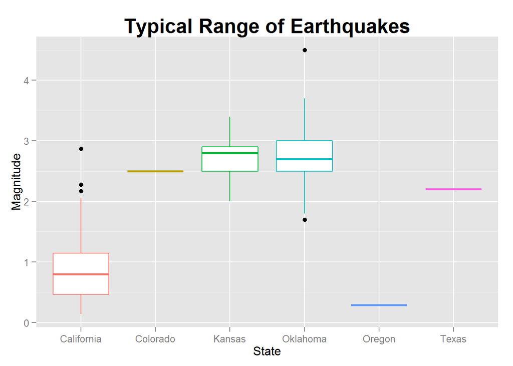

```
##
## > p2
```

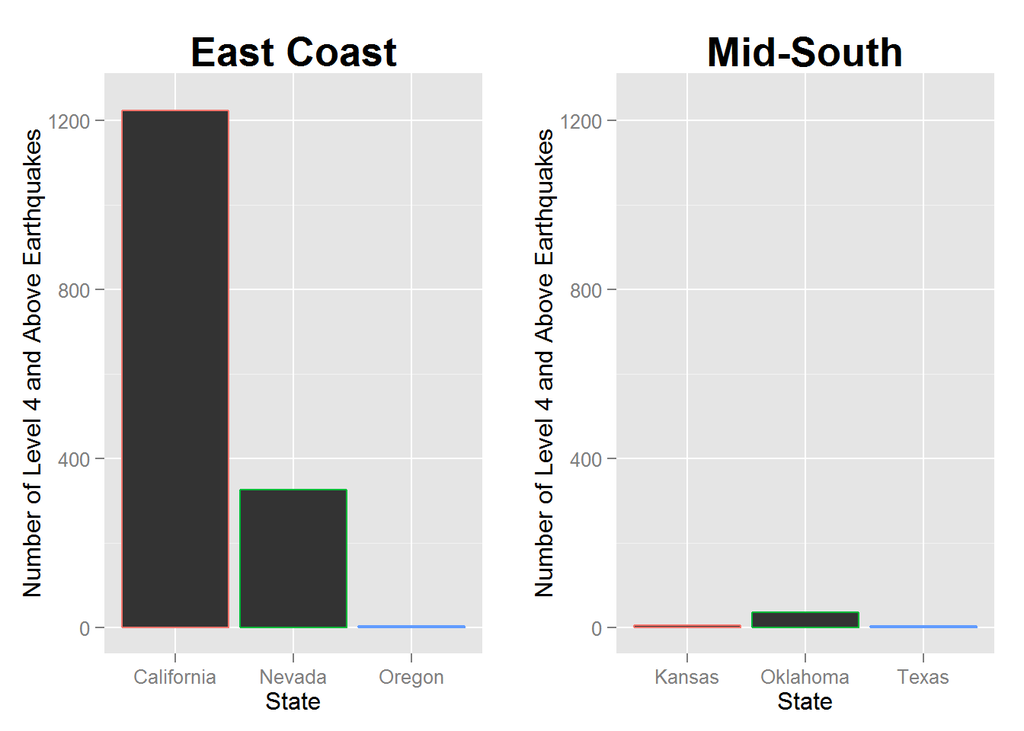

```
##
## > pushViewport(viewport(layout = grid.layout(1, 2)))
##
## > print(p3, vp = viewport(layout.pos.row = 1, layout.pos.col = 1))
##
## > print(p4, vp = viewport(layout.pos.row = 1, layout.pos.col = 2))
```

This source code was created to display a collection of data plots as one PNG image.

```r
#source("../03 Visualizations/PNG .R", echo = TRUE)
```

A characterization of the categorical columns as group by plots.

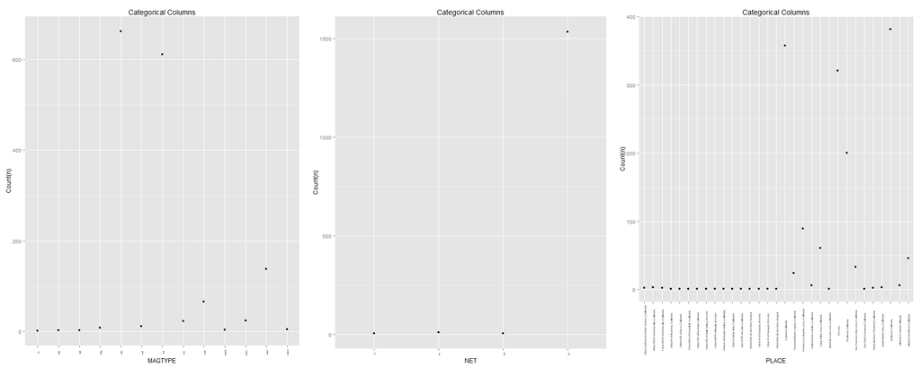

A characterization of the measure columns as histograms.

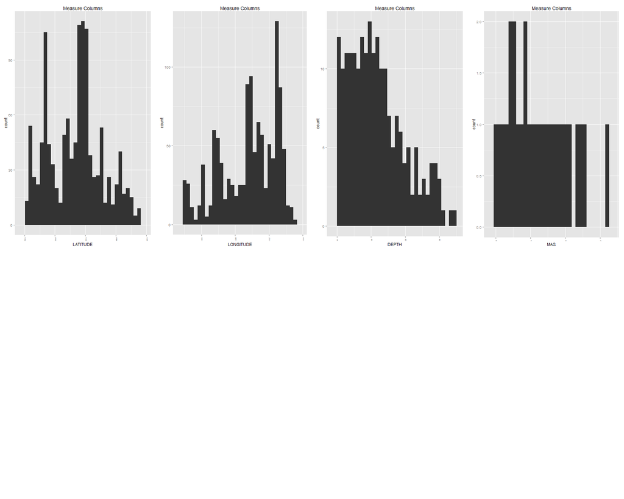